# Experimental Sociology - Week 05 - In Class

- Show All Code
- Hide All Code
- View Source

Evolutionary ABMs: Basics

Published

2025-04-30

# Task 1: Why 00000 and 00001 represent the same strategies

## The difference

- 00000
  - Always defects
- 00001
  - Similar, but cooperates if both strategies had cooperated before.
  - However, “CD” and “CC” (that is where ego cooperates) can never be reached.
  - Therefore it is irrelevant which values appear at these positions.
- This only holds as long as the behavior is deterministic (no random elements, e.g., errors).

## Some stratgies

- aD (always Defection):
  - 00000, 00001, 00101, 00100
- aC (always Cooperate)
  - 11111, 10111, 10101, 11101
- Tit-For-Tat
  - 10011
- Grimm Trigger
  - 10001

# Task 2: Play around!

## My Simulation

```r
simulation  <- list(
  model = "baseline",
  replications = 15,
  tbl_parameter = expand.grid(
    mu = 0.1,                       # needed or expand.grid would not work well with `expected_rounds`
    expected_rounds = list(c(2, 2),
                           c(4, 4),
                           c(8, 8),
                           c(16, 16))
  ),
  master_seed  = 42,
  max_cores    = 15
)
```

## Result

**Show R Code (Summary plot)**

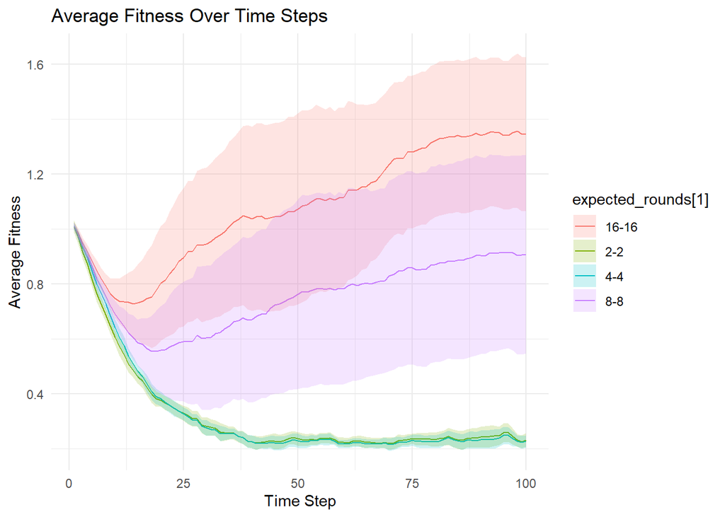

Figure 1: Average fitness over time for different length of rounds.

```r
source("../data/abm-pd/week05_inclass_script_01.R", chdir = TRUE)
print(p)
```

# Task 3: Possible changes to `update_agents()`

## Brainstorming

- Currently: All agents have the same chance to become “changers”

  - ```
    Instead: Only the worst x% become changers
    ```

  - ```
    In case of a network structure: integrate that
    ```

- Currently: All imitators copy the strategy perfectly
  - Add a chance that an imitator copies the strategy imperfectly
  - This could replace the need for mutators
- Currently: Number of imitators and mutators are fixed

  - ```
    Determine randomly whether a individual changer becomes a imitator or a mutators
    ```

# Task 4: Now lets implement that!

## Lets Tackle This

Determine randomly whether a individual changer becomes a imitator or a mutators

## Status-Quo

```
  # 1. Choose all agents that will change
  n_update <- round(model$mu * n)
  changers <- sample(seq_len(n), n_update)

  # 2. Randomly split into mutators and imitators
  n_mutate  <- round(model$mu_rnd * n_update)
  mutators  <- sample(changers, n_mutate)
  imitators <- setdiff(changers, mutators)
```

## Lets change the second part into:

```
  # 2. Randomly split into mutators and imitators
  mut_ids <- runif(length(changers)) < model$mu_rnd    # TRUE → mutate
  mutators  <- changers[ mut_ids ]
  imitators <- changers[!mut_ids ]
```

- But do not replace it, write a if-clause to keep the old and the new

## If-clause

```
  if model$my_self_explanatory_variable = SOMETHING {
    # old code
  } else {
    # new code
  }
```

## My If-clause

```
  if model$mutators_n_fixed = TRUE {
    # old code
  } else {
    # new code
  }
```

## Copyright

Copyright Sascha Grehl, 2025. All Rights Reserved